# 置換行列とR

- 7月11日のミーティングをまとめつつ、置換行列を題材にRのスキルを向上することにします

## 主な内容

- 三角メッシュな平面グラフの双対グラフの辺接続行列$We$が２つの置換行列の和$We=Wc+Wd$であることを学んだ
- $Wc$と$Wd$には次のような関係があることも学んだ

$$Wd = P Wc^T P$$

ただし$P$は、
$$P^{-1} = P^T = P\\
PP = PP^T = P^T P = PP^{-1} =P^{-1}P = I$$
なる置換行列。

- $Wc Wd = Wx$ という行列が置換行列であること、その巡回路は、グラフで言えば、辺を一つ飛ばしにしているので、一つ飛ばしにしないサイクルが存在すること

## 単位行列を作る

```r
d <- 8
# d次単位行列
Id <- diag(d)
Id
```

```
##      [,1] [,2] [,3] [,4] [,5] [,6] [,7] [,8]
## [1,]    1    0    0    0    0    0    0    0
## [2,]    0    1    0    0    0    0    0    0
## [3,]    0    0    1    0    0    0    0    0
## [4,]    0    0    0    1    0    0    0    0
## [5,]    0    0    0    0    1    0    0    0
## [6,]    0    0    0    0    0    1    0    0
## [7,]    0    0    0    0    0    0    1    0
## [8,]    0    0    0    0    0    0    0    1
```

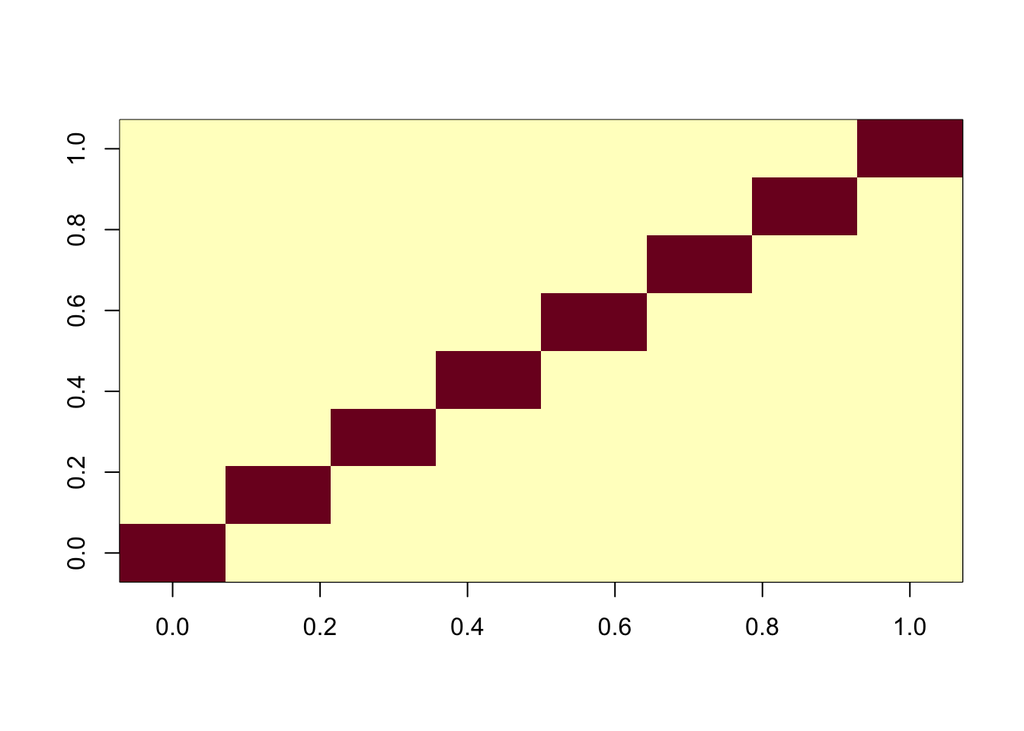

```r
image(Id)
```

行和、列和の確認

```r
apply(Id,1,sum) # 行（第二引数=1）の和
```

```
## [1] 1 1 1 1 1 1 1 1
```

```r
apply(Id,2,sum) # 列（第二引数=2) の和
```

```
## [1] 1 1 1 1 1 1 1 1
```

## 置換行列を作る

置換行列は、(1,2,…,d)の順列sを作成し、Idの列の順序をそのsの順にすることで作成できる。

順列sを作成する。

```r
s <- sample(d) # 「長さがsのランダム順列を作る」
s
```

```
## [1] 5 6 8 4 3 7 1 2
```

```r
# こうもできる
s. <- sample(1:d) # 「1,2,...,dをシャッフルする」
s.
```

```
## [1] 3 7 8 2 4 1 6 5
```

順列を使って、Idの列を入れ替える。

```r
Wc <- Id[,s]
Wc
```

```
##      [,1] [,2] [,3] [,4] [,5] [,6] [,7] [,8]
## [1,]    0    0    0    0    0    0    1    0
## [2,]    0    0    0    0    0    0    0    1
## [3,]    0    0    0    0    1    0    0    0
## [4,]    0    0    0    1    0    0    0    0
## [5,]    1    0    0    0    0    0    0    0
## [6,]    0    1    0    0    0    0    0    0
## [7,]    0    0    0    0    0    1    0    0
## [8,]    0    0    1    0    0    0    0    0
```

```r
Wc[s[1],1]
```

```
## [1] 1
```

```r
Wc[s[2],2]
```

```
## [1] 1
```

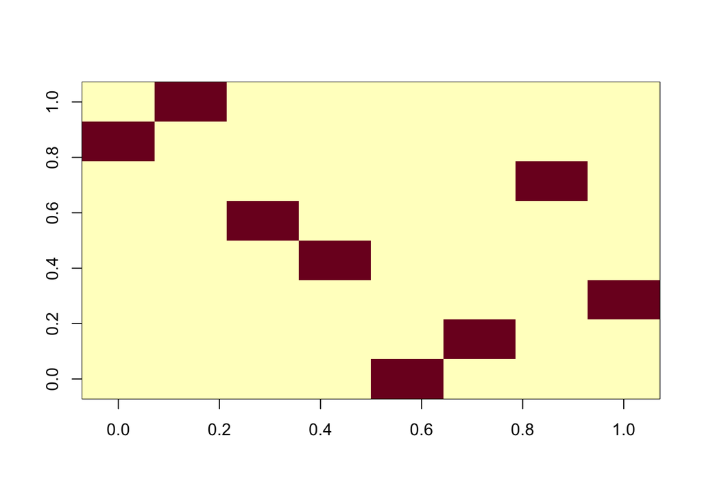

```r
image(Wc)
```

## 特別な置換行列Pを作る

Pは、1,2,…,dのペアを作る訳なので、1,2,…,dのランダム順列を２列に並べることで、ランダムなペアを作れる。

```r
sp <- sample(d)
sp
```

```
## [1] 1 4 2 5 6 7 3 8
```

```r
sp.pair <- matrix(sp,ncol=2)
sp.pair
```

```
##      [,1] [,2]
## [1,]    1    6
## [2,]    4    7
## [3,]    2    3
## [4,]    5    8
```

dxd行列Pを作る。

```r
P <- matrix(0,d,d)
for(i in 1:length(sp.pair[,1])){
  P[sp.pair[i,1],sp.pair[i,2]] <- 1
  P[sp.pair[i,2],sp.pair[i,1]] <- 1
}
P
```

```
##      [,1] [,2] [,3] [,4] [,5] [,6] [,7] [,8]
## [1,]    0    0    0    0    0    1    0    0
## [2,]    0    0    1    0    0    0    0    0
## [3,]    0    1    0    0    0    0    0    0
## [4,]    0    0    0    0    0    0    1    0
## [5,]    0    0    0    0    0    0    0    1
## [6,]    1    0    0    0    0    0    0    0
## [7,]    0    0    0    1    0    0    0    0
## [8,]    0    0    0    0    1    0    0    0
```

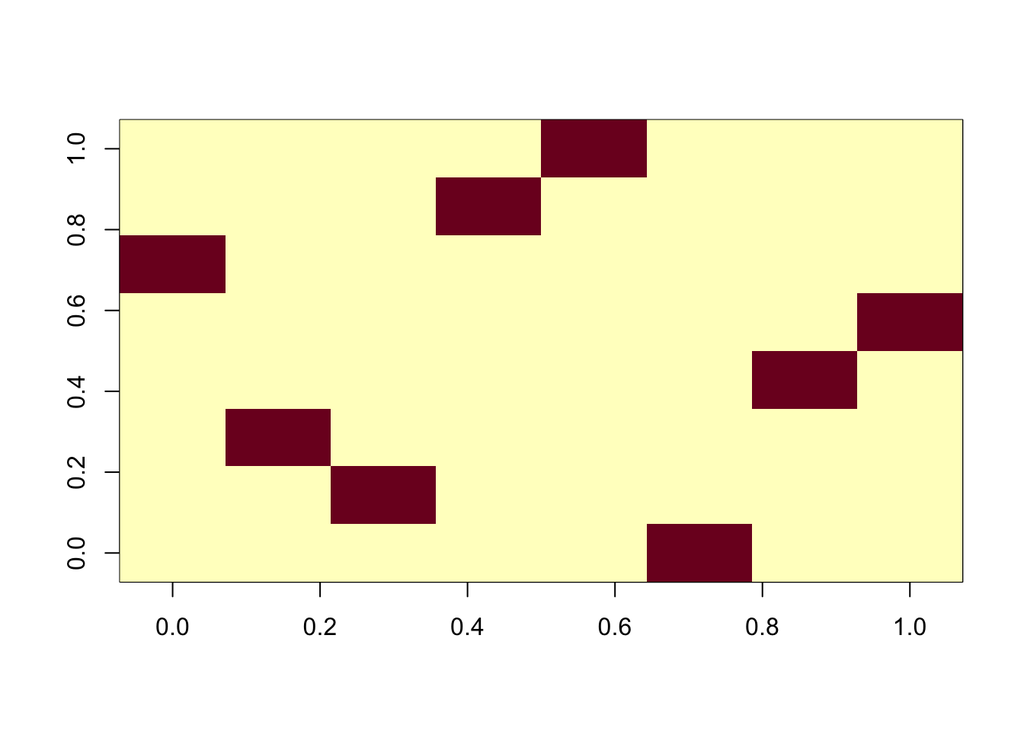

```r
image(P)
```

Pの性質を確認する。

$P^2=I$の確認。

```r
P %*% P - Id
```

```
##      [,1] [,2] [,3] [,4] [,5] [,6] [,7] [,8]
## [1,]    0    0    0    0    0    0    0    0
## [2,]    0    0    0    0    0    0    0    0
## [3,]    0    0    0    0    0    0    0    0
## [4,]    0    0    0    0    0    0    0    0
## [5,]    0    0    0    0    0    0    0    0
## [6,]    0    0    0    0    0    0    0    0
## [7,]    0    0    0    0    0    0    0    0
## [8,]    0    0    0    0    0    0    0    0
```

全成分を視認するのは面倒なので、以下のように確認することもできる。

```r
range(P %*% P - Id)
```

```
## [1] 0 0
```

$P = P^T$の確認。

```r
range(P- t(P))
```

```
## [1] 0 0
```

$P = P^{-1}$の確認($P^2=I$で確認されているといえば、そうなのだが）。

```r
range(P- solve(P))
```

```
## [1] 0 0
```

$P P^T = I$の確認。

```r
range(P %*% t(P) - Id)
```

```
## [1] 0 0
```

## WdをWcとPとから作る

$$Wd <- P Wc^T P$$

```r
Wd <- P %*% t(Wc) %*% P
Wd
```

```
##      [,1] [,2] [,3] [,4] [,5] [,6] [,7] [,8]
## [1,]    0    0    0    1    0    0    0    0
## [2,]    0    0    0    0    1    0    0    0
## [3,]    1    0    0    0    0    0    0    0
## [4,]    0    0    0    0    0    1    0    0
## [5,]    0    0    1    0    0    0    0    0
## [6,]    0    0    0    0    0    0    0    1
## [7,]    0    0    0    0    0    0    1    0
## [8,]    0    1    0    0    0    0    0    0
```

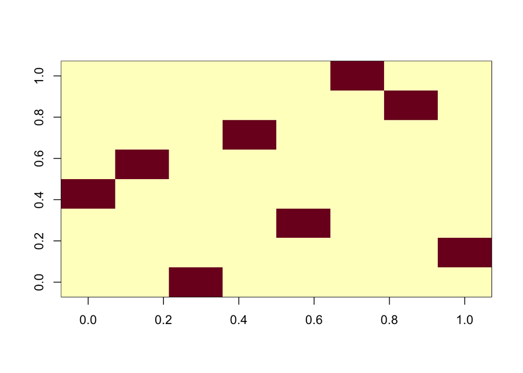

```r
image(Wd)
```

置換行列であることの確認（行和・列和が全て１で、全成分が0 か１。

```r
apply(Wd,1,sum) # 行和
```

```
## [1] 1 1 1 1 1 1 1 1
```

```r
apply(Wd,2,sum) # 列和
```

```
## [1] 1 1 1 1 1 1 1 1
```

```r
table(Wd) # 成分の値別の個数の表示。0,1しかない
```

```
## Wd
##  0  1
## 56  8
```

## $Wx = Wc %*% Wd$ の作成とその置換行列、巡回置換分解

### $Wx$の置換行列確認

$Wx$を作る。

```r
Wx <- Wc %*% Wd
Wx
```

```
##      [,1] [,2] [,3] [,4] [,5] [,6] [,7] [,8]
## [1,]    0    0    0    0    0    0    1    0
## [2,]    0    1    0    0    0    0    0    0
## [3,]    0    0    1    0    0    0    0    0
## [4,]    0    0    0    0    0    1    0    0
## [5,]    0    0    0    1    0    0    0    0
## [6,]    0    0    0    0    1    0    0    0
## [7,]    0    0    0    0    0    0    0    1
## [8,]    1    0    0    0    0    0    0    0
```

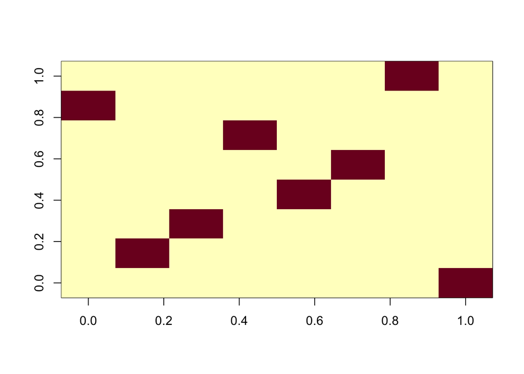

```r
image(Wx)
```

```r
apply(Wx,1,sum)
```

```
## [1] 1 1 1 1 1 1 1 1
```

```r
apply(Wx,2,sum)
```

```
## [1] 1 1 1 1 1 1 1 1
```

```r
table(Wx)
```

```
## Wx
##  0  1
## 56  8
```

### 置換行列からの巡回取り出し

巡回は、長さdのベクトルのうち、１成分のみが１で残りが０であるようなベクトル（基底ベクトル）に、置換行列の1,2,…乗をかけて得られるベクトルの値１の成分の列として現れる。

d乗までやれば必ず巡回が現れるから、全ての基底ベクトルに、その作業を行ってみる。

```r
power.d.series <- list()
for(i in 1:d){
  # i-th基底ベクトルを作る
  v <- rep(0,d)
  v[i] <- 1
  # 巡回情報格納用のベクトルをリストのi-th要素として指定する
  power.d.series[[i]] <- rep(0,d+1)
  power.d.series[[i]][1] <- i # 初期値代入
  v.now <- v
  for(j in 1:d){
    v.now <- Wx %*% v.now # v.now の更新
    # v.nowの値が１の成分を取り出して記録する
    power.d.series[[i]][j+1] <- which(v.now==1)
  }
}
power.d.series
```

```
## [[1]]
## [1] 1 8 7 1 8 7 1 8 7
##
## [[2]]
## [1] 2 2 2 2 2 2 2 2 2
##
## [[3]]
## [1] 3 3 3 3 3 3 3 3 3
##
## [[4]]
## [1] 4 5 6 4 5 6 4 5 6
##
## [[5]]
## [1] 5 6 4 5 6 4 5 6 4
##
## [[6]]
## [1] 6 4 5 6 4 5 6 4 5
##
## [[7]]
## [1] 7 1 8 7 1 8 7 1 8
##
## [[8]]
## [1] 8 7 1 8 7 1 8 7 1
```

全情報を眺めわたせば、巡回がわかるが、大規模な場合には目視ではできっこないので、巡回を取り出す方法を考える

出力リストのそれぞれの要素には、巡回が存在している。 その巡回は、前から辿って、第一成分に戻るまでとなるから、それを取り出す。

リストの各成分について同じことを繰り返せば良いが、一度、ある巡回に含まれることがわかった成分については、調べ直す必要はないから、1,2,…,dが、検出された巡回に含まれているか否かを記録しながら進めることにする。

```r
# サイクル記録用のリストオブジェクト
cycles <- list()
# 何個のサイクルが見つかるかわからないので
# 見つけたサイクルが何番目かを知るためのカウンタを回すことにする
cnt <- 1
# 既検出サイクルに含まれているかの記録用ベクトル
found <- rep(0,d) # 処理前は全て、未検出=0
for(i in 1:d){
  if(found[i] == 0){ # i番目が見検出なら、処理をする
    tmp <- power.d.series[[i]] # この数列からサイクルを取り出す
    # tmpの第一成分は？
    tmp.v1 <- tmp[1]
    # tmpの第一成分と同じ値を持つ成分は？
    sames <- which(tmp == tmp.v1)
    # サイクルは、tmpの第一成分と同じ値を持つ成分の２番目の一つ手前まで
    new.cycle <- tmp[1:(sames[2]-1)]
    # 新たなサイクルをcnt番目のサイクルとして登録
    cycles[[cnt]] <- new.cycle
    # 次に登録するサイクルが何番目になるかの情報を更新する
    cnt <- cnt + 1
    # このサイクルに出てきたidを既検出登録する
    found[new.cycle] <- 1
  }
}
cycles
```

```
## [[1]]
## [1] 1 8 7
##
## [[2]]
## [1] 2
##
## [[3]]
## [1] 3
##
## [[4]]
## [1] 4 5 6
```

検算しておく。

取り出した成分は、必ず1,2,…,d1が１度ずつのはず

```r
# リストというデータ構造を壊してベクトル化する
cycle.elem <- unlist(cycles)
cycle.elem
```

```
## [1] 1 8 7 2 3 4 5 6
```

一回ずつ出たかを調べたい。

目視でやるなら：

```r
sort(cycle.elem) - 1:d
```

```
## [1] 0 0 0 0 0 0 0 0
```

こうしておくと、数が多くなっても安心。

```r
range(sort(cycle.elem) - 1:d)
```

```
## [1] 0 0
```

## 問題

Wxについて巡回が取り出せた。

$Wx = Wc %*% Wd$なので Wc,Wdを交互にかけあわせながら、値の変遷履歴を取ることは、上記を少しいじると可能なはず。

値の変遷履歴から、巡回を取り出すこともできる。

問題は、「１度、巡回に現れたら、もう処理しなくて良いか」というと、そうではない点。

どうやって解決するか。

作戦を立てる。

power.d.seriesに相当するもののそれぞれから、巡回を取り出す。

取り出した巡回は、始点が異なると、異なったもののように見えるが、何かしらの工夫で、同一視できるはずである。

同一視の方法としては、取り出したサイクルの構成要素の最小のものを、先頭に並び替えるという処理をすると、サイクルのフェーズ違いを無視して同一確認できるはず。

以下のような処理がそれに相当する。

```r
C1 <- c(3,6,1,5) # あるサイクルがこのように出たとする
# この中の最小値の番地は
min.address <- which(C1==min(C1))
min.address
```

```
## [1] 3
```

```r
C1[min.address]
```

```
## [1] 1
```

最小値番地を先頭に、並び替えるには次のようにできる

```r
len <- length(C1) # サイクルのながさ
sorted.C1 <- C1[c(min.address:len,1:((min.address-1)))]
sorted.C1
```

```
## [1] 1 5 3 6
```

注意事項が１つある。C1の第一成分がすでに最小値のとき、失敗する。

```r
C2 <- c(2,6,3,4)
min.address <- which(C2==min(C2))
min.address
```

```
## [1] 1
```

```r
C2[min.address]
```

```
## [1] 2
```

```r
len <- length(C2) # サイクルのながさ
sorted.C2 <- C2[c(min.address:len,1:((min.address-1)))]
sorted.C2
```

```
## [1] 2 6 3 4 2
```

ちょっと工夫をする。

```r
C2 <- c(2,6,3,4)
min.address <- which(C2==min(C2))

if(min.address == 1) {
  sorted.C2 <- C2
}else{
  sorted.C2 <- C2[c(min.address:len,1:((min.address-1)))]
}
sorted.C2
```

```
## [1] 2 6 3 4
```

これなら、C1でも同じように動く。

```r
C2 <- C1 #
C2
```

```
## [1] 3 6 1 5
```

```r
min.address <- which(C2==min(C2))

if(min.address == 1) {
  sorted.C2 <- C2
}else{
  sorted.C2 <- C2[c(min.address:len,1:((min.address-1)))]
}
sorted.C2
```

```
## [1] 1 5 3 6
```